# 02_comparacion_obs

Pao

June 10, 2019

## SATWND

La idea es comparar los datos de viento del GOES que se usaron durante relampago con los que están disponibles en el prepbufr (SATWND). Cómo tengo prepbufr para ventanas de 1 hora centradas voy a comparar las obs de las 18 UTC del 20181120 (o sea las obs entre las 17:30 y las 18:30) con las observaciones en ese período.

```r
obs_pb <- fread('../obs_PREPBUFR/20182011_18_prepbufr.csv',
                na.strings = "100000000000.000")
colnames(obs_pb) <- c("obs.id", "time", "station", "lon", "lat", "dhr", "sub.id", "station.elev", "p", "q", "t", "elev", "u", "v", "pwo", "cat", "press")

obs_pb[, time := ymd_h(time)]
obs_pb[, time.obs := time + as.period(as.duration(days(x=1))*(dhr/24))]

obs_pb <- obs_pb[obs.id == "SATWND"] %>%
  .[lon %between% c(290, 310) & lat %between% c(-40, -20)]

#Le saco variables

knitr::kable(obs_pb[, .N, by = .(sub.id)])
```

| sub.id | N |
| --- | --- |
| 253 | 153 |
| 243 | 89 |
| 254 | 161 |

```r
obs_pb <- obs_pb[, list(lon, lat, p, u, v, time.obs)] %>%
  melt(., measure.vars = c("u", "v"), variable.name = "obs.id", value.name = "obs") %>%
  .[obs.id == "u", obs.id := "2819"] %>%
  .[obs.id == "v", obs.id := "2820"] %>%
  .[, source := "prepbufr"]
```

Estos son los typos de observación dentro de “SATWND” y corresponden a:

| Report Type | PREPBUFR Message Type | Description | Ind. |
| --- | --- | --- | --- |
| 241 | SATWND | INDIA IR AND VISIBLE CLOUD DRIFT U, V (INSAT-2E) | + |
| 242 | SATWND | JMA IR AND VISIBLE CLOUD DRIFT U, V AT LEVELS BELOW 850 MB (GMS-5) | A |
| **243** | **SATWND** | **EUMETSAT IR AND VISIBLE CLOUD DRIFT U, V AT LEVELS BELOW 850 MB (METEOSAT-5, METEOSAT-7)** | **A** |
| 244 | —— | currently not used | n/a |
| 245 | SATWND | NESDIS IR CLOUD DRIFT U, V (GOES-8, GOES-10) | A |
| 246 | SATWND | NESDIS IMAGER WATER VAPOR CLOUD U, V AT CLOUD TOP (GOES-8, GOES-10) | A |
| 247 | SATWND | NESDIS IMAGER WATER VAPOR CLOUD U, V - DEEP LAYER (GOES-8, GOES-10) | * |
| 248 | SATWND | NESDIS SOUNDER WATER VAPOR CLOUD U, V AT CLOUD TOP (GOES-8, GOES-10) | * |
| 249 | SATWND | NESDIS SOUNDER WATER VAPOR CLOUD U, V - DEEP LAYER (GOES-8, GOES-10) | * |
| 250 | SATWND | JMA WATER VAPOR CLOUD U, V (GMS-5) | + |
| 251 | SATWND | NESDIS VISIBLE CLOUD DRIFT U, V (GOES-8, GOES-10) | + |
| 252 | SATWND | JMA IR AND VISIBLE CLOUD DRIFT U, V AT LEVELS ABOVE 850 MB (GMS-5) | A |
| **253** | **SATWND** | **EUMETSAT IR AND VISIBLE CLOUD DRIFT U, V AT LEVELS ABOVE 850 MB (METEOSAT-5, METEOSAT-7)** | **A** |
| **254** | **SATWND** | **EUMETSAT WATER VAPOR CLOUD U, V (METEOSAT-5, METEOSAT-7)** | **+** |
| 255 | SATWND | NESDIS PICTURE TRIPLET CLOUD U, V (GOES-8, GOES-10) | A |
| 256 | SATWND | INDIA WATER VAPOR CLOUD U, V (INSAT-2E) | * |

Así que entiendo que GOES-16 no estaría llegando a los prepbufrs…

```r
obs_rra <- read.obs('../obs_RRA/20181120_18/*0.dat', keep.obs = c(2819,2820)) %>%
  rbind(read.obs('../obs_RRA/20181120_19/*0.dat', keep.obs = c(2819,2820)))

#Filtro solo lo que necesito (time range, dominio, tipo de u,v)
obs_rra <- obs_rra[time %between% c(as_datetime("2018-11-20 17:30:00"), as_datetime("2018-11-20 18:30:00"))] %>%
  .[sub.id == 4] %>%  #Asumo que sub.id = 4  es para los datos del goes porque son muchísimos y al graficar podrían tener pinta
  .[lon %between% c(290, 310) & lat %between% c(-40, -20)]

obs_rra <- obs_rra[, list(lon, lat, elev, time, obs.id, obs)] %>%
  .[, source := "rra"]

setnames(obs_rra, old = c("time", "elev"), new = c("time.obs", "p"))

# Ojo! la elevación está en hectopascales!
```

Tengo dos datatable con el mismo formato, vamos a ver que pinta tienen.

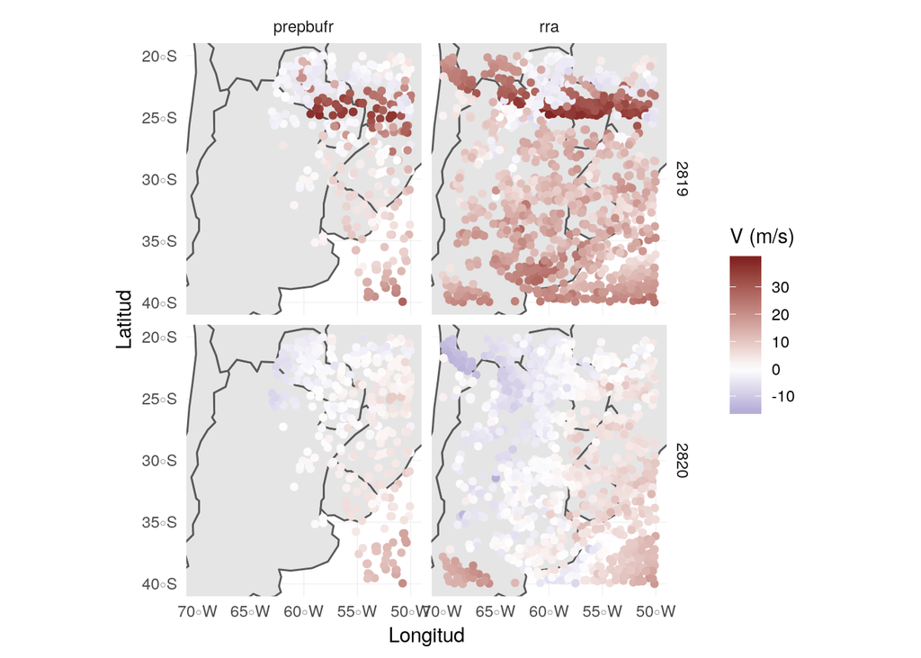

```r
obs <- rbind(obs_pb, obs_rra)

map <- rnaturalearth::ne_countries(continent = 'south america', scale = 'small', returnclass = 'sf')

ggplot(obs, aes(ConvertLongitude(lon), lat)) +
  geom_sf(data = map, inherit.aes = FALSE) +
  coord_sf(xlim = c(-70, -50), ylim = c(-40, -20)) +
  geom_point(aes(color = obs)) +
  scale_color_divergent(name = "V (m/s)") +
  scale_x_continuous(name = "Longitud") +
  scale_y_continuous(name = "Latitud") +
  facet_grid(obs.id~source) +
  theme_minimal()
```

En la figura se comparan las observaciones de los dos dataset. Los datos usados para el RRA son más y tienen mayor covertura respecto de los que vienen en el prepbufr. Según las referencias de prepbufr los datos son de Eumesat, no me queda claro si esto incluye o no a los vientos del GOES. Lo intenresante es que el patrón se corresponde entre los dos data sets.

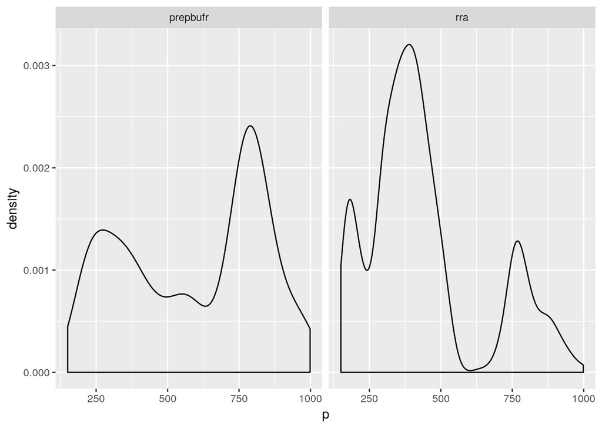

```r
ggplot(obs, aes(p)) +
 geom_density() +
 facet_wrap(~source)
```

Vamos a intentar convertir la variable p (continua) en capaz (factores) para ver la distribución espacial por niveles.

Definimos:

- Nivel bajo: 1000 - 600 hPa.
- Nivel medio: 600 - 300 hPa.
- Nivel alto: menor a 300 hPa.

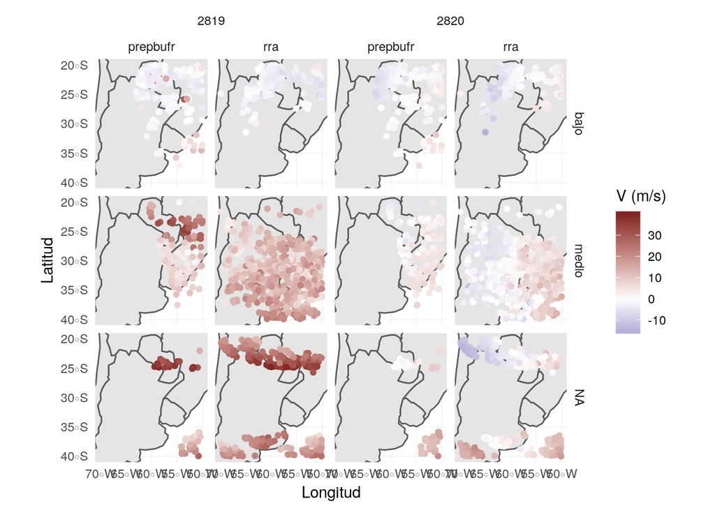

```r
obs[p %between% c(600, 1000), lev := "bajo"] %>%
  .[p %between% c(300, 600), lev := "medio"] %>%
  .[p %between% c(300, 100), lev := "alto"]

obs[] %>%
  ggplot(aes(ConvertLongitude(lon), lat)) +
  geom_sf(data = map, inherit.aes = FALSE) +
  coord_sf(xlim = c(-70, -50), ylim = c(-40, -20)) +
  geom_point(aes(color = obs)) +
  scale_color_divergent(name = "V (m/s)") +
  scale_x_continuous(name = "Longitud") +
  scale_y_continuous(name = "Latitud") +
  facet_nested(lev~obs.id + source) +
  theme_minimal()
```

Si bien el patrón general se mantiene, esmás fácil ver algunas diferencias. En niveles bajos el prepbufr tiene algunos datos anomalamente? altos, da la sensación de ser errores porque no aparecen en el otro set de datos y están en una región con viento zonal casi nulo. En niveles medios las diferencias son más importantes: La región de viento zonal fuerte sobre el este de Paraguay que muestra el prepbufr no se observa en el otro dataset. Se me ocurre que puede haber un problema con la estimación de los niveles y que esos puntos en realidad corresponden a niveles altos.

## AIRCFT

Hagamos el mismo análisis pero para datos de aviones. En el prepbufr estos datos están codificados con “AIRCFT” y en los datos del RRA corresponden al subtipo 3.

| Report Type | PREPBUFR Message Type | Description | Ind. |
| --- | --- | --- | --- |
| 230 | AIRCFT | AIREP AND PIREP AIRCRAFT U, V | A |
| 231 | AIRCFT | ASDAR AIRCRAFT U, V | A |

```r
# prepbufr
obs_pb <- fread('../obs_PREPBUFR/20182011_18_prepbufr.csv',
                na.strings = "100000000000.000")
colnames(obs_pb) <- c("obs.id", "time", "station", "lon", "lat", "dhr", "sub.id", "station.elev", "p", "q", "t", "elev", "u", "v", "pwo", "cat", "press")

obs_pb[, time := ymd_h(time)]
obs_pb[, time.obs := time + as.period(as.duration(days(x=1))*(dhr/24))]

obs_pb <- obs_pb[obs.id == "AIRCFT"] %>%
  .[lon %between% c(290, 310) & lat %between% c(-40, -20)]

obs_pb <- obs_pb[, list(lon, lat, p, u, v, time.obs)] %>%
  melt(., measure.vars = c("u", "v"), variable.name = "obs.id", value.name = "obs") %>%
  .[obs.id == "u", obs.id := "2819"] %>%
  .[obs.id == "v", obs.id := "2820"] %>%
  .[, source := "prepbufr"]

# RRA
obs_rra <- read.obs('../obs_RRA/20181120_18/*0.dat', keep.obs = c(2819,2820)) %>%
  rbind(read.obs('../obs_RRA/20181120_19/*0.dat', keep.obs = c(2819,2820)))

#Filtro solo lo que necesito (time range, dominio, tipo de u,v)
obs_rra <- obs_rra[time %between% c(as_datetime("2018-11-20 17:30:00"), as_datetime("2018-11-20 18:30:00"))] %>%
  .[sub.id == 3] %>%
  .[lon %between% c(290, 310) & lat %between% c(-40, -20)]

obs_rra <- obs_rra[, list(lon, lat, elev, time, obs.id, obs)] %>%
  .[, source := "rra"]

setnames(obs_rra, old = c("time", "elev"), new = c("time.obs", "p"))

# La unión
obs <- rbind(obs_pb, obs_rra)
```

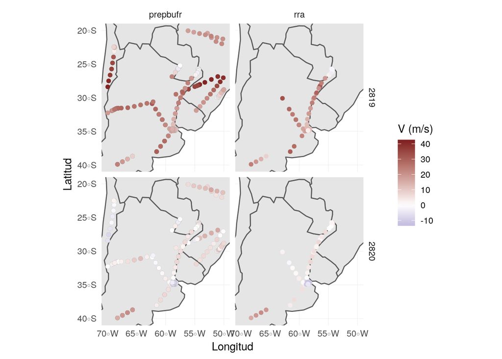

```r
map <- rnaturalearth::ne_countries(continent = 'south america', scale = 'small', returnclass = 'sf')

ggplot(obs, aes(ConvertLongitude(lon), lat)) +
  geom_sf(data = map, inherit.aes = FALSE) +
  coord_sf(xlim = c(-70, -50), ylim = c(-40, -20)) +
  geom_point(aes(color = obs)) +
  scale_color_divergent(name = "V (m/s)") +
  scale_x_continuous(name = "Longitud") +
  scale_y_continuous(name = "Latitud") +
  facet_grid(obs.id~source) +
  theme_minimal()
```

Bueno, buenas noticias! Al parecer los prepbufrs tienen más observaciones de aviones que el RRA y por suerte las que están en el RRA también están en el prepbufr.

## AIRS

En principio los prepbufrs no tienen datos de AIRS, pero deberían estar en un bufr aparte ¿serán los mismo datos?

En los dato susados en RRA el subtipo para AIRS es 21. Pero no tengo ninguno en este tiempo.